# ml4econ Classification and Tree methods

Dor Meir

may 21 2019

## Part 1: Logistic regression and LDA and QDA

1. We will use the Weekly dataset from the ISLR package (and use MASS and dplyr as well). View it, and check for NA’s and irrelevant variables.

```r
library(ISLR)
library(MASS)
library(dplyr)
dat <- Weekly
attach(dat)
str(dat)
```

```
## 'data.frame':    1089 obs. of  9 variables:
##  $ Year     : num  1990 1990 1990 1990 1990 1990 1990 1990 1990 1990 ...
##  $ Lag1     : num  0.816 -0.27 -2.576 3.514 0.712 ...
##  $ Lag2     : num  1.572 0.816 -0.27 -2.576 3.514 ...
##  $ Lag3     : num  -3.936 1.572 0.816 -0.27 -2.576 ...
##  $ Lag4     : num  -0.229 -3.936 1.572 0.816 -0.27 ...
##  $ Lag5     : num  -3.484 -0.229 -3.936 1.572 0.816 ...
##  $ Volume   : num  0.155 0.149 0.16 0.162 0.154 ...
##  $ Today    : num  -0.27 -2.576 3.514 0.712 1.178 ...
##  $ Direction: Factor w/ 2 levels "Down","Up": 1 1 2 2 2 1 2 2 2 1 ...
```

```r
head(dat)
```

```
##   Year   Lag1   Lag2   Lag3   Lag4   Lag5    Volume  Today Direction
## 1 1990  0.816  1.572 -3.936 -0.229 -3.484 0.1549760 -0.270      Down
## 2 1990 -0.270  0.816  1.572 -3.936 -0.229 0.1485740 -2.576      Down
## 3 1990 -2.576 -0.270  0.816  1.572 -3.936 0.1598375  3.514        Up
## 4 1990  3.514 -2.576 -0.270  0.816  1.572 0.1616300  0.712        Up
## 5 1990  0.712  3.514 -2.576 -0.270  0.816 0.1537280  1.178        Up
## 6 1990  1.178  0.712  3.514 -2.576 -0.270 0.1544440 -1.372      Down
```

```r
dat[!complete.cases(dat),]
```

```
## [1] Year      Lag1      Lag2      Lag3      Lag4      Lag5      Volume
## [8] Today     Direction
## <0 rows> (or 0-length row.names)
```

There are no missing values, and there is only 1 factor variable: Direction, all other variables are numberic. For binomial and quasibinomial families the response, in our case Direction, can also be specified as a factor. Coding Direction to 0,1 level factor:

```r
dat$Direction <- ifelse(dat$Direction=="Up",1,0)
```

2. Preform logistic regression using the full data set with direction as the response variable and the five lag variables and volume as predictors. Are any predictors statistically significant? If so, which ones?

```r
glm_model<-glm(formula = Direction ~ Lag1 + Lag2 + Lag3 + Lag4 + Lag5  + Volume,data = dat,family = "binomial")
summary(glm_model)
```

```
##
## Call:
## glm(formula = Direction ~ Lag1 + Lag2 + Lag3 + Lag4 + Lag5 +
##     Volume, family = "binomial", data = dat)
##
## Deviance Residuals:
##     Min       1Q   Median       3Q      Max
## -1.6949  -1.2565   0.9913   1.0849   1.4579
##
## Coefficients:
##             Estimate Std. Error z value Pr(>|z|)
## (Intercept)  0.26686    0.08593   3.106   0.0019 **
## Lag1        -0.04127    0.02641  -1.563   0.1181
## Lag2         0.05844    0.02686   2.175   0.0296 *
## Lag3        -0.01606    0.02666  -0.602   0.5469
## Lag4        -0.02779    0.02646  -1.050   0.2937
## Lag5        -0.01447    0.02638  -0.549   0.5833
## Volume      -0.02274    0.03690  -0.616   0.5377
## ---
## Signif. codes:  0 '***' 0.001 '**' 0.01 '*' 0.05 '.' 0.1 ' ' 1
##
## (Dispersion parameter for binomial family taken to be 1)
##
##     Null deviance: 1496.2  on 1088  degrees of freedom
## Residual deviance: 1486.4  on 1082  degrees of freedom
## AIC: 1500.4
##
## Number of Fisher Scoring iterations: 4
```

Only Lag2’s predictor is siginificant at the level of 5% and the intercept is significant at the level of 1%.

3. Fit logistic regression using a training set from 1990 till 2008, with lag2 as the only predictor. Compute the confusion matrix on the test data (2009 and 2010).

First, create train and test sets, and the new glm model:

```r
train_dat <- subset(dat, Year<2009)
summary(train_dat$Year)
```

```
##    Min. 1st Qu.  Median    Mean 3rd Qu.    Max.
##    1990    1994    1999    1999    2004    2008
```

```r
test_dat <- subset(dat, Year>=2009)
summary(test_dat$Year)
```

```
##    Min. 1st Qu.  Median    Mean 3rd Qu.    Max.
##    2009    2009    2010    2010    2010    2010
```

```r
glm2<-glm(formula = Direction ~ Lag2,data = train_dat,family = "binomial")
summary(glm2)
```

```
##
## Call:
## glm(formula = Direction ~ Lag2, family = "binomial", data = train_dat)
##
## Deviance Residuals:
##    Min      1Q  Median      3Q     Max
## -1.536  -1.264   1.021   1.091   1.368
##
## Coefficients:
##             Estimate Std. Error z value Pr(>|z|)
## (Intercept)  0.20326    0.06428   3.162  0.00157 **
## Lag2         0.05810    0.02870   2.024  0.04298 *
## ---
## Signif. codes:  0 '***' 0.001 '**' 0.01 '*' 0.05 '.' 0.1 ' ' 1
##
## (Dispersion parameter for binomial family taken to be 1)
##
##     Null deviance: 1354.7  on 984  degrees of freedom
## Residual deviance: 1350.5  on 983  degrees of freedom
## AIC: 1354.5
##
## Number of Fisher Scoring iterations: 4
```

Second, predict Direction_hat:

```r
Direction_hat <- predict(glm2,type="response",newdata = test_dat)
```

we need to choose a threshold in order to compute the confusion matrix with respect to the values in the test set, as in the classification pdf p 15.Here is a plot of the prediction’s accuracy, sensitivity and specificity for different thresholds in the train set:

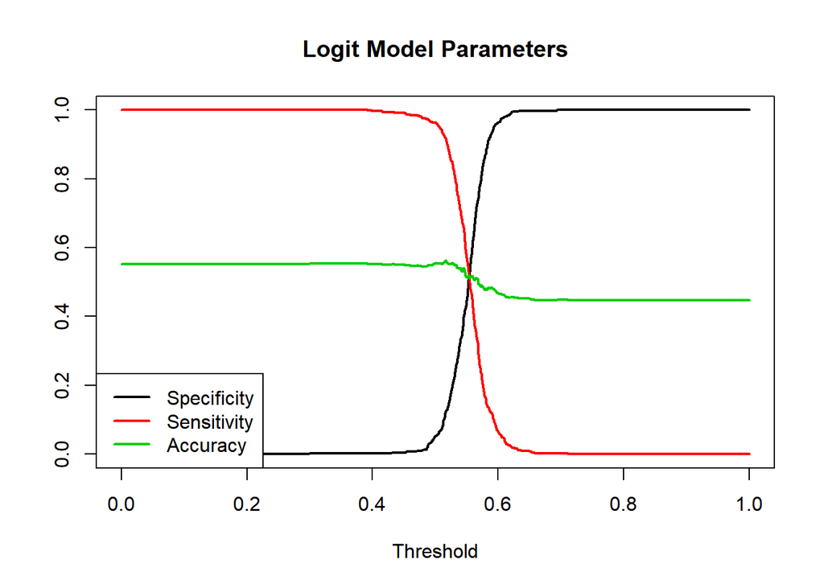

we can see that ~0.5 is a threshold that creates a very low specificity (high chances of type 1 error), and with high power (low chances of type 2 error). If we assume a loss-averter decision-maker, who cares more about losing than about gaining money, the maximal errors with respect to type 2 error will be set to 10%. Given this decision rule I will minimize the type 1 error (maximize the sensitivity).

```r
restricted_conf <- which(confusion_design[3,]>0.1)
max_index <- which.max(confusion_design[2,restricted_conf])
chosen_threshold <- confusion_design[1, max_index]
```

The maximizer is 0.592

```r
confusion_lgm2 <- table(test_dat$Direction, ifelse(Direction_hat>=chosen_threshold, 1, 0))
confusion_lgm2
```

```
##
##      0  1
##   0 39  4
##   1 47 14
```

4. Repeat 3 using, LDA.

```r
lda_train <- lda(formula = Direction ~ Lag2, data = train_dat)
test_hat_lda <- predict(lda_train, newdata = test_dat, type = "response")
confusion_lda <- table(test_dat$Direction, test_hat_lda$class)
confusion_lda
```

```
##
##      0  1
##   0  9 34
##   1  5 56
```

5. Repeat 3 using QDA.

```r
qda_train <- qda(formula = Direction ~ Lag2, data = train_dat)
train_hat_qda <- predict(qda_train, newdata = test_dat, type = "response")
confusion_qda <- table(test_dat$Direction, train_hat_qda$class)
confusion_qda
```

```
##
##      0  1
##   0  0 43
##   1  0 61
```

6. Analyze the results Compare between the methods.

```r
conf_matrix_prop <- function(conf_matrix) {

  TP <- conf_matrix[2,2]
  FP <- conf_matrix[1,2]
  FN <- conf_matrix[2,1]
  TN <- conf_matrix[1,1]

  False_Positive_Rate <- FP / (TN + FP) # 1 - Specificity (type 1 error)
  True_Positive_Rate <- TP / (TP + FN) # Sensitivity (or Power)
  Positive_Predictive_Value <- TP / (FP + TP) # Precision
  Negative_Predictive_Value <- TN / (TN + FN)
  Accuracy <- (TP + TN) / (TP + TN + FP + FN)
  Error_Rate <- (FP + FN) / (TP + TN + FP + FN)

  result <- c(False_Positive_Rate, True_Positive_Rate, Positive_Predictive_Value, Negative_Predictive_Value, Accuracy, Error_Rate)
  names(result) <- c("False Positive Rate", "True Positive Rate", "Positive Predictive Value", "Negative Predictive Value", "Accuracy", "Error Rate")

  return(result)
}

list(Logistic = confusion_lda,"Logistic Properties" = conf_matrix_prop(confusion_lgm2), LDA = confusion_lda, "LDA Properties" = conf_matrix_prop(confusion_lda),QDA = confusion_qda, "QDA Properties" = conf_matrix_prop(confusion_qda))
```

[output not shown]

## Part 2: Tree Based methods

1. We will use the Carseats dataset from the ISLR package to predict the variable Sales. I’ll load the tree, randomForest and gbm packages for the Trees, Random-Forests and Bagging and Boosting models (respectively)

```r
library(tree)
library(randomForest)
library(gbm)
```

I’ll now Import the *Carseats* data and as usual: inspect it, examine the structure and check for missing values:

```r
carseats <- Carseats
head(carseats)
```

```
##   Sales CompPrice Income Advertising Population Price ShelveLoc Age
## 1  9.50       138     73          11        276   120       Bad  42
## 2 11.22       111     48          16        260    83      Good  65
## 3 10.06       113     35          10        269    80    Medium  59
## 4  7.40       117    100           4        466    97    Medium  55
## 5  4.15       141     64           3        340   128       Bad  38
## 6 10.81       124    113          13        501    72       Bad  78
##   Education Urban  US
## 1        17   Yes Yes
## 2        10   Yes Yes
## 3        12   Yes Yes
## 4        14   Yes Yes
## 5        13   Yes  No
## 6        16    No Yes
```

```r
str(carseats)
```

```
## 'data.frame':    400 obs. of  11 variables:
##  $ Sales      : num  9.5 11.22 10.06 7.4 4.15 ...
##  $ CompPrice  : num  138 111 113 117 141 124 115 136 132 132 ...
##  $ Income     : num  73 48 35 100 64 113 105 81 110 113 ...
##  $ Advertising: num  11 16 10 4 3 13 0 15 0 0 ...
##  $ Population : num  276 260 269 466 340 501 45 425 108 131 ...
##  $ Price      : num  120 83 80 97 128 72 108 120 124 124 ...
##  $ ShelveLoc  : Factor w/ 3 levels "Bad","Good","Medium": 1 2 3 3 1 1 3 2 3 3 ...
##  $ Age        : num  42 65 59 55 38 78 71 67 76 76 ...
##  $ Education  : num  17 10 12 14 13 16 15 10 10 17 ...
##  $ Urban      : Factor w/ 2 levels "No","Yes": 2 2 2 2 2 1 2 2 1 1 ...
##  $ US         : Factor w/ 2 levels "No","Yes": 2 2 2 2 1 2 1 2 1 2 ...
```

```r
which(is.na(carseats))
```

```
## integer(0)
```

The dataset is of sales of child car seats at 400 different stores. The data contains 11 varaibles (8 numeric, 2 two-level factors, 1 three-level factor) and 400 observations, and no missing values were found.

2. Split the data into training and test sets:

```r
set.seed(1234)
index <- sample(1:nrow(carseats), size=.25*nrow(carseats))
test_carseats <-carseats[index,]
train_carseats <- carseats[-index,]
```

3. Fit a regression tree to the training set. Plot the tree and discuss the results. What are the test MSE results?

First, I’ll grow the tree:

```r
tree <- tree( Sales ~ . , train_carseats )
summary(tree)
```

```
##
## Regression tree:
## tree(formula = Sales ~ ., data = train_carseats)
## Variables actually used in tree construction:
## [1] "ShelveLoc"   "Price"       "CompPrice"   "Income"      "Advertising"
## Number of terminal nodes:  16
## Residual mean deviance:  2.502 = 710.6 / 284
## Distribution of residuals:
##     Min.  1st Qu.   Median     Mean  3rd Qu.     Max.
## -5.17600 -0.95880  0.05711  0.00000  1.09300  4.82600
```

Now, I’ll Plot of the tree:

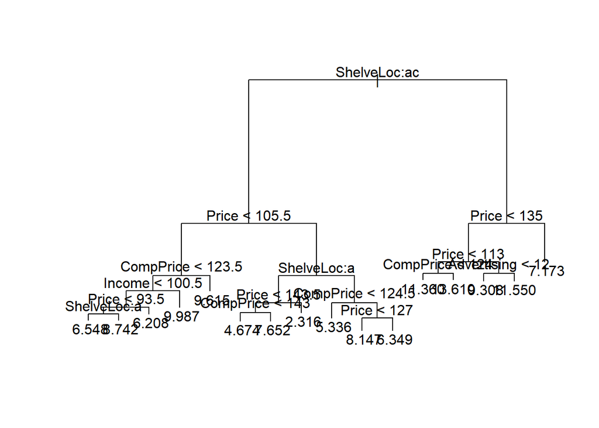

Calculating the MSE:

```r
Sales_hat_tree <- predict(tree, test_carseats)

MSE_calc <- function(real, prediction) {
  result <- mean((prediction-real)^2)
  return(result)
}

MSE_calc(test_carseats$Sales, Sales_hat_tree)
```

```
## [1] 4.601248
```

4. Use cross validation in order to determine the optimal level of tree complexity. Does pruning the tree improve the test MSE?

I use 5-fold CV:

```r
cv_tree <- cv.tree(tree, K = 5)
final_terminal_nodes = cv_tree$size[which.min(cv_tree$dev)]
```

And now plot of the results:

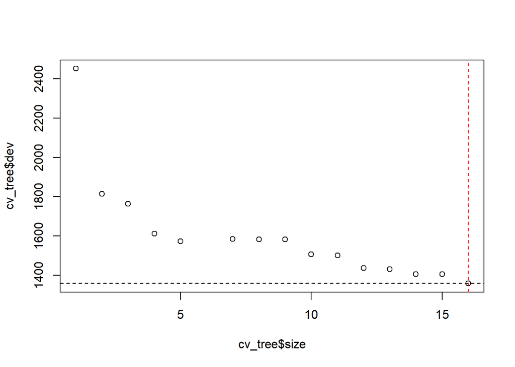

The minimizer is 16 - which is the entire tree, as we saw before. Even though, it does not seems wise to use the whole tree, so I will pay a little in terms of deviation and choose a smaller tree.

The MSE of the new pruned tree:

```r
tree_pruned <- prune.tree(tree, best = final_terminal_nodes-2)
Sales_hat_tree_pruned <- predict(tree_pruned, test_carseats)
MSE_calc(test_carseats$Sales,Sales_hat_tree_pruned)
```

```
## [1] 4.662673
```

And as we can see, we now have a bit higher MSE since we used a smaller number of terminal nodes than the minizer suggests…

5. Apply the Bagging (random forest with the maximum number of variables), random forests and boosting approaches. Use the importance() function to determine (where possible) which variables are most important.

```r
bagging <- randomForest(formula =  Sales ~ . , data = train_carseats, mtry = 10, importance = TRUE)
boosting <- gbm(formula =  Sales ~ . , data = train_carseats, distribution = "gaussian")
random_forests <- randomForest(formula =  Sales ~ . , data = train_carseats, mtry = round(sqrt(10)), importance = TRUE)
```

The estimated importance matrix in the *Bagging* and *Random-Forests* algorithms:

```r
importance(bagging)
```

```
##                %IncMSE IncNodePurity
## CompPrice   29.8093142    247.507183
## Income      11.7841328    123.366473
## Advertising 23.4279182    173.188155
## Population   0.3713072     82.000631
## Price       69.8841572    682.493607
## ShelveLoc   76.5424938    798.031784
## Age         18.0602949    178.466993
## Education    3.7076643     62.568718
## Urban       -0.1027630      8.574776
## US           2.4236214      9.743416
```

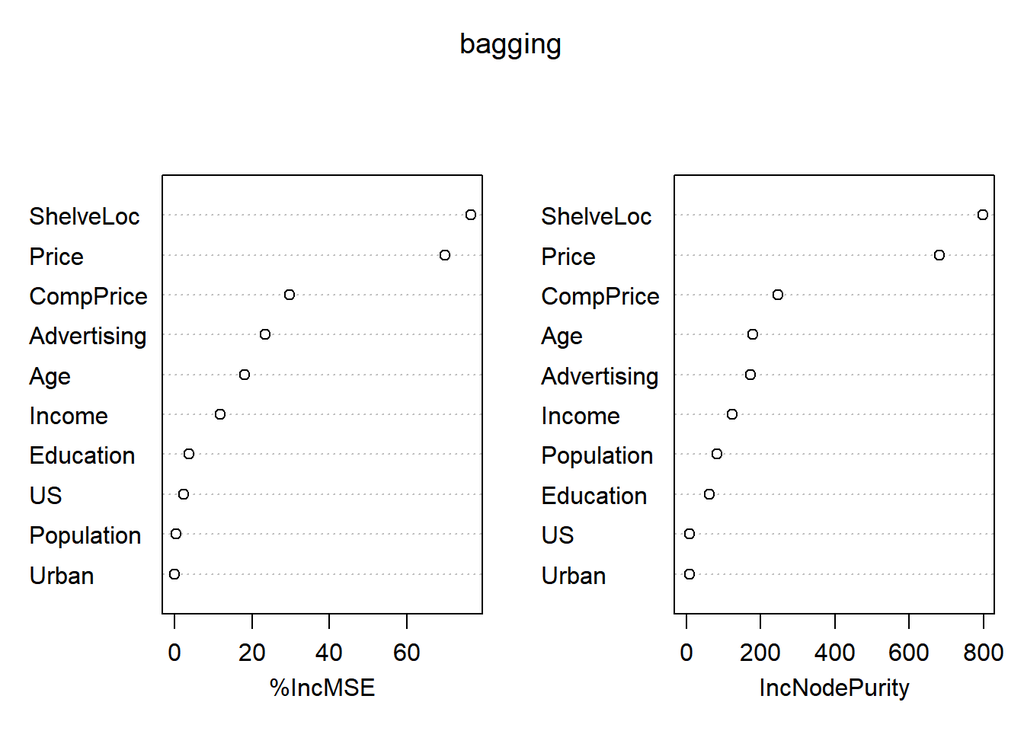

```r
varImpPlot(bagging)
```

```r
importance(random_forests)
```

```
##                 %IncMSE IncNodePurity
## CompPrice   16.47133700     214.80245
## Income       7.32172757     173.53240
## Advertising 21.95601694     236.21475
## Population  -1.67405982     154.42987
## Price       40.52500070     538.44117
## ShelveLoc   50.39145703     591.38907
## Age         14.32716162     239.93417
## Education    2.95366221     102.57291
## Urban       -0.06836643      17.80520
## US           4.43416719      23.83377
```

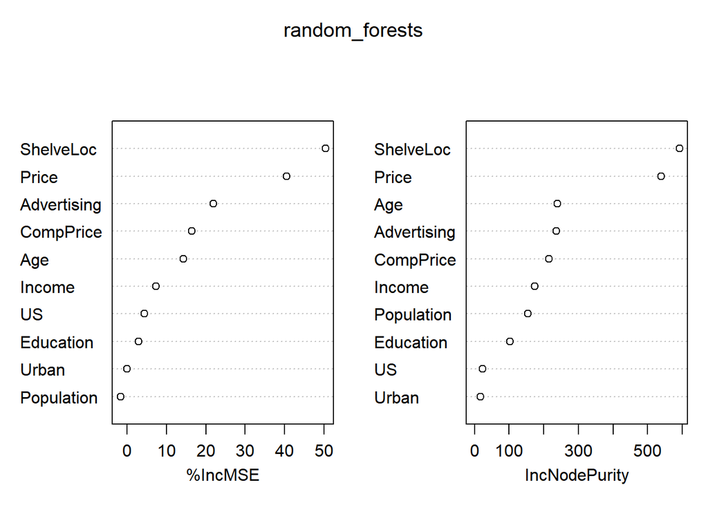

```r
varImpPlot(random_forests)
```

```r
summary.gbm(boosting)
```

```
##                     var   rel.inf
## ShelveLoc     ShelveLoc 37.442475
## Price             Price 32.615621
## CompPrice     CompPrice 10.096298
## Advertising Advertising  9.175640
## Age                 Age  7.656317
## Income           Income  3.013648
## Population   Population  0.000000
## Education     Education  0.000000
## Urban             Urban  0.000000
## US                   US  0.000000
```

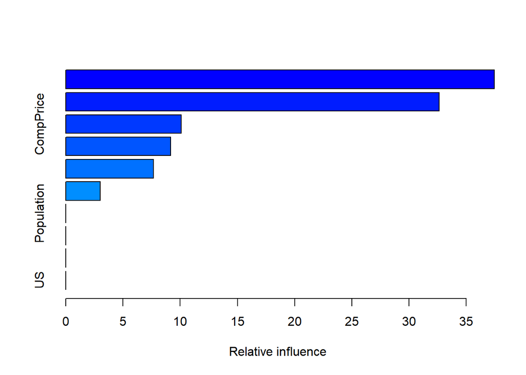

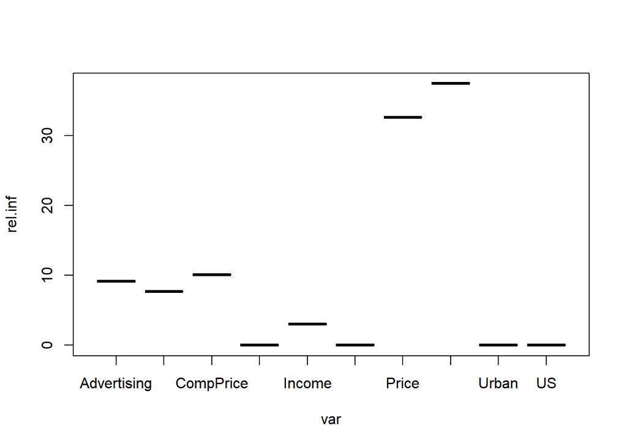

```r
plot(summary.gbm(boosting))
```

SheleveLoc and Price seems to be the most important features, both in the bagging, random_forests and boosting, as permuting them results in the highest %IncMSE (change in MSE) .

6. Discuss and compare the results.

The MSEs:

```r
Sales_hat_bagging <- predict(bagging, test_carseats)
Sales_hat_boosting <- predict(boosting, test_carseats, n.trees = boosting$n.trees)
Sales_hat_random_forests <- predict(random_forests, test_carseats)

MSE_calc(test_carseats$Sales,Sales_hat_bagging)
```

```
## [1] 2.618152
```

```r
MSE_calc(test_carseats$Sales,Sales_hat_boosting)
```

```
## [1] 2.47121
```

```r
MSE_calc(test_carseats$Sales,Sales_hat_random_forests)
```

```
## [1] 3.023096
```

% Var explained:

```r
random_forests
```

```
##
## Call:
##  randomForest(formula = Sales ~ ., data = train_carseats, mtry = round(sqrt(10)),      importance = TRUE)
##                Type of random forest: regression
##                      Number of trees: 500
## No. of variables tried at each split: 3
##
##           Mean of squared residuals: 2.766603
##                     % Var explained: 65.65
```

```r
bagging
```

```
##
## Call:
##  randomForest(formula = Sales ~ ., data = train_carseats, mtry = 10,      importance = TRUE)
##                Type of random forest: regression
##                      Number of trees: 500
## No. of variables tried at each split: 10
##
##           Mean of squared residuals: 2.479161
##                     % Var explained: 69.22
```

And as you can see, the boosting’s MSE is lowest (each new tree of the model helps to correct errors made by previously trained tree), but above we can see that more variation is explained in the bagging model (since it’s trees are grown deep and not pruned). The advantage of the random forest model is that each tree is trained independently, using a random sample of the data, which makes the model more robust and less likley to overfit the training data.

THE END.